# proj3

Adya Joshi | UID: 117196306 | DirectoryID: ajoshi15

Project 3: Gapminder | CMSC320, Fall 2022

```python
#Initial Data Import

import pandas as pd
import numpy as np
import matplotlib.pyplot as mp
import seaborn as sb
import statsmodels.formula.api as sma
import sklearn
from sklearn.linear_model import LinearRegression

data = pd.read_csv("08_gap-every-five-years.tsv", sep='\t')
data.head()
```

|  | country | continent | year | lifeExp | pop | gdpPercap |
| --- | --- | --- | --- | --- | --- | --- |
| 0 | Afghanistan | Asia | 1952 | 28.801 | 8425333 | 779.445314 |
| 1 | Afghanistan | Asia | 1957 | 30.332 | 9240934 | 820.853030 |
| 2 | Afghanistan | Asia | 1962 | 31.997 | 10267083 | 853.100710 |
| 3 | Afghanistan | Asia | 1967 | 34.020 | 11537966 | 836.197138 |
| 4 | Afghanistan | Asia | 1972 | 36.088 | 13079460 | 739.981106 |

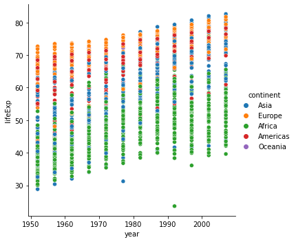

```python
#Part 1, Exercise 1

sb.relplot(data = data, x='year', y='lifeExp', hue='continent')
mp.show()
```

Part 1, Question 1

The general trend is that life expectancies are increasing, however, they don't seem to be increasing at the same rate for each continent. This trend appears to be linear.

Part 1, Question 2

I would describe the distribution of life expectancy across countries for individual years to be skewed for the most part. While the skew changes throughout the years, the distributions are definitely not perfect. You can see that as the years go, the distributions skew towards the top showing that life expectancy is increasing. For the most part, these are not symmetric around their centers and show a stark difference in life expectancies by continent as well. While these start as bimodal, they seem to be getting more and more unimodal from 1987 onwards.

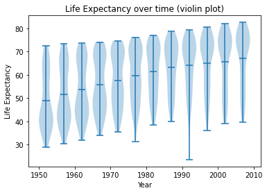

```python
#Part 1, Question 3
#Code for Violin Plot

dy = data['year'].unique()
dgy = data.groupby('year')['lifeExp'].apply(list)
lgy = []

for i in dgy.index:
    lgy.append(dgy[i])

f, a = mp.subplots()
a.violinplot(lgy, dy, widths=4, showmeans=True)
a.set_xlabel("Year")
a.set_ylabel("Life Expectancy")
a.set_title("Life Expectancy over time (violin plot)")
```

Part 1, Question 3

Yes, I would reject the null hypothesis since just by looking at the violin plot and the plot from Exercise 1, there seems to be a relationship between life expectancy and year. Life expectancy seems to be increasing each year. Now, in more general data science research and conclusions, one might be inclined to say that not just the year, but the advances in medical care, increasing peacetime, etc, might be the driving factors. However, there remains a relationship between life expectancy and year in a more general sense.

Part 1, Question 4

I would expect a violin plot of the residuals to have similar looking distributions as the violin plot of the actual life expectancies. Since we see a linear relationship I would expect the center of the residuals' distribution to be near 0.

Part 1, Question 5

According to the assumptions of the linear regression model, the residual's distribution for each year should center around 0.

```python
#Part 1, Exercise 2

regy = sma.ols(formula='lifeExp ~ year', data=data).fit()
print(regy.summary())
```

```
                            OLS Regression Results
==============================================================================
Dep. Variable:                lifeExp   R-squared:                       0.190
Model:                            OLS   Adj. R-squared:                  0.189
Method:                 Least Squares   F-statistic:                     398.6
Date:                Fri, 02 Dec 2022   Prob (F-statistic):           7.55e-80
Time:                        04:20:50   Log-Likelihood:                -6597.9
No. Observations:                1704   AIC:                         1.320e+04
Df Residuals:                    1702   BIC:                         1.321e+04
Df Model:                           1
Covariance Type:            nonrobust
==============================================================================
                 coef    std err          t      P>|t|      [0.025      0.975]
------------------------------------------------------------------------------
Intercept   -585.6522     32.314    -18.124      0.000    -649.031    -522.273
year           0.3259      0.016     19.965      0.000       0.294       0.358
==============================================================================
Omnibus:                      386.124   Durbin-Watson:                   0.197
Prob(Omnibus):                  0.000   Jarque-Bera (JB):               90.750
Skew:                          -0.268   Prob(JB):                     1.97e-20
Kurtosis:                       2.004   Cond. No.                     2.27e+05
==============================================================================

Notes:
[1] Standard Errors assume that the covariance matrix of the errors is correctly specified.
[2] The condition number is large, 2.27e+05. This might indicate that there are
strong multicollinearity or other numerical problems.
```

Part 1, Question 6

On average, the life expectancy increases by 0.3259 each year. Which means, each year the life expectancy increases by about a third of a year.

Part 1, Question 7

I reject the null hypothesis since the P value is 0.

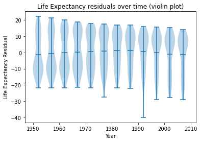

```python
#Part 1, Question 3

data['residuals'] = 0
for index, row in data.iterrows():
    data.at[index, 'residuals'] = row['lifeExp'] - (pl[index])

dgyr = data.groupby('year')['residuals'].apply(list)
lgyr = []

for i in dgyr.index:
    lgyr.append(dgyr[i])

f, a = mp.subplots()
a.violinplot(lgyr, dy, widths=4, showmeans=True)
a.set_xlabel("Year")
a.set_ylabel("Life Expectancy Residual")
a.set_title("Life Expectancy residuals over time (violin plot)")
```

Part 1, Question 8

Yes, this matches my expectations since the distributions look similar between the two violin plots. This also shows that the centers of the residuals' distributions are near 0.

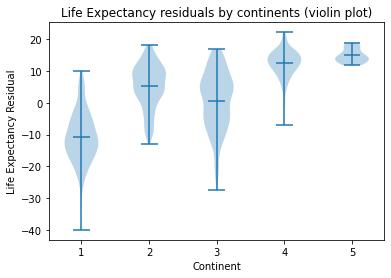

[output not shown]

```python
#Part 1, Exercise 4

dgyc = data.groupby('continent')['residuals'].apply(list)
lgyc = []

for i in dgyc.index:
    lgyc.append(dgyc[i])

cnames = ['Asia', 'Europe', 'Africa', 'Americas', 'Oceania']
f, a = mp.subplots()
a.violinplot(lgyc, showmeans=True)
a.set_xlabel("Continent")
a.set_ylabel("Life Expectancy Residual")
a.set_title("Life Expectancy residuals by continents (violin plot)")
mp.show()

print("LEGEND")
print("1: Asia")
print("2: Europe")
print("3: Africa")
print("4: Americas")
print("5: Oceania")
```

Part 1, Question 9

Yes, there a dependence between the model residual and continent. One can see this through the varying distributions, shapes, and positions that present for each continent. This might suggest that when performing a regression analysis of life expectancy across time, it would not actually be accurate unless continent is also taken into account.

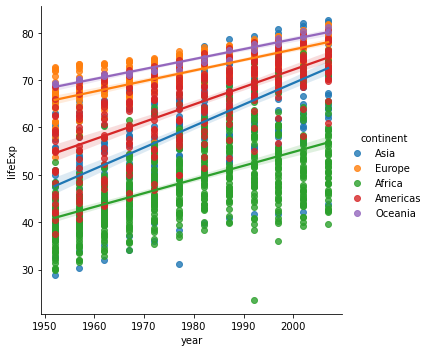

```python
#Part 1, Exercise 5

sb.lmplot(data = data, x='year', y='lifeExp', hue='continent')
mp.show()
```

Part 1, Question 10

Yes, my regression model should have an interaction term for continent based on this plot. This plot shows that each continent has a different looking line that fits it and the slopes and intercepts seem to both be quite different.

```python
#Part 1, Exercise 6 (Part A)

regsc = sma.ols(formula='lifeExp ~ year : continent', data=data).fit()
print(regsc.summary())
```

```
                            OLS Regression Results
==============================================================================
Dep. Variable:                lifeExp   R-squared:                       0.680
Model:                            OLS   Adj. R-squared:                  0.679
Method:                 Least Squares   F-statistic:                     721.4
Date:                Fri, 02 Dec 2022   Prob (F-statistic):               0.00
Time:                        04:49:10   Log-Likelihood:                -5806.5
No. Observations:                1704   AIC:                         1.163e+04
Df Residuals:                    1698   BIC:                         1.166e+04
Df Model:                           5
Covariance Type:            nonrobust
============================================================================================
                               coef    std err          t      P>|t|      [0.025      0.975]
--------------------------------------------------------------------------------------------
Intercept                 -585.6522     20.334    -28.802      0.000    -625.534    -545.770
year:continent[Africa]       0.3205      0.010     31.204      0.000       0.300       0.341
year:continent[Americas]     0.3285      0.010     31.978      0.000       0.308       0.349
year:continent[Asia]         0.3262      0.010     31.754      0.000       0.306       0.346
year:continent[Europe]       0.3322      0.010     32.334      0.000       0.312       0.352
year:continent[Oceania]      0.3334      0.010     32.372      0.000       0.313       0.354
==============================================================================
Omnibus:                       21.747   Durbin-Watson:                   0.254
Prob(Omnibus):                  0.000   Jarque-Bera (JB):               25.918
Skew:                          -0.200   Prob(JB):                     2.36e-06
Kurtosis:                       3.454   Cond. No.                     1.37e+05
==============================================================================

Notes:
[1] Standard Errors assume that the covariance matrix of the errors is correctly specified.
[2] The condition number is large, 1.37e+05. This might indicate that there are
strong multicollinearity or other numerical problems.
```

```python
#Part 1, Exercise 6 (Part B)

#This was done solely to show the differences, but Part A should be considered better since it includes a linear regression model for Africa. I also answer Q11 and 12 using the model in Part A.

regss = sma.ols(formula='lifeExp ~ year * continent', data=data).fit()
print(regss.summary())
#Using a '*' removes Africa and absorbs it in the intercept
```

```
                            OLS Regression Results
==============================================================================
Dep. Variable:                lifeExp   R-squared:                       0.693
Model:                            OLS   Adj. R-squared:                  0.691
Method:                 Least Squares   F-statistic:                     424.3
Date:                Fri, 02 Dec 2022   Prob (F-statistic):               0.00
Time:                        04:49:22   Log-Likelihood:                -5771.9
No. Observations:                1704   AIC:                         1.156e+04
Df Residuals:                    1694   BIC:                         1.162e+04
Df Model:                           9
Covariance Type:            nonrobust
==============================================================================================
                                 coef    std err          t      P>|t|      [0.025      0.975]
----------------------------------------------------------------------------------------------
Intercept                   -524.2578     32.963    -15.904      0.000    -588.911    -459.605
continent[T.Americas]       -138.8484     57.851     -2.400      0.016    -252.315     -25.382
continent[T.Asia]           -312.6330     52.904     -5.909      0.000    -416.396    -208.870
continent[T.Europe]          156.8469     54.498      2.878      0.004      49.957     263.737
continent[T.Oceania]         182.3499    171.283      1.065      0.287    -153.599     518.298
year                           0.2895      0.017     17.387      0.000       0.257       0.322
year:continent[T.Americas]     0.0781      0.029      2.673      0.008       0.021       0.135
year:continent[T.Asia]         0.1636      0.027      6.121      0.000       0.111       0.216
year:continent[T.Europe]      -0.0676      0.028     -2.455      0.014      -0.122      -0.014
year:continent[T.Oceania]     -0.0793      0.087     -0.916      0.360      -0.249       0.090
==============================================================================
Omnibus:                       27.121   Durbin-Watson:                   0.242
Prob(Omnibus):                  0.000   Jarque-Bera (JB):               44.106
Skew:                          -0.121   Prob(JB):                     2.65e-10
Kurtosis:                       3.750   Cond. No.                     2.09e+06
==============================================================================

Notes:
[1] Standard Errors assume that the covariance matrix of the errors is correctly specified.
[2] The condition number is large, 2.09e+06. This might indicate that there are
strong multicollinearity or other numerical problems.
```

Part 1 Question 11

The P-value is 0, so the parameters are all significantly different from zero.

Part 1, Question 12

On average, the life expectancy increases each year for each continent by the following values:

Africa: 0.3205

Americas: 0.3285

Asia: 0.3262

Europe: 0.3322

Oceania: 0.3334

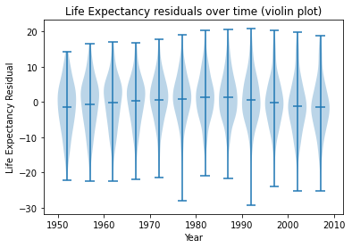

```python
#Part 1, Exercise 7

data['residualsPred'] = 0
plm = regsc.predict(data)
for index, row in data.iterrows():
    data.at[index, 'residualsPred'] = row['lifeExp'] - (plm[index])

dgym = data.groupby('year')['residualsPred'].apply(list)
lgym = []

for i in dgym.index:
    lgym.append(dgym[i])

f, a = mp.subplots()
a.violinplot(lgym, dy, widths=4, showmeans=True)
a.set_xlabel("Year")
a.set_ylabel("Life Expectancy Residual")
a.set_title("Life Expectancy residuals over time (violin plot)")
```

Part 1, Exercise 7

The violin plot is very close to the assumption of the linear regression model since the means are all very close to zero. The distributions for each year are also approximately symmetric around the mean.

```python
#Part 2: Code (initialization)
from sklearn.datasets import load_wine
from sklearn.tree import DecisionTreeClassifier
from sklearn.neighbors import KNeighborsClassifier
from sklearn.model_selection import train_test_split, cross_val_score
from sklearn.preprocessing import StandardScaler
from sklearn.tree import export_graphviz
from sklearn.metrics import confusion_matrix

wine = load_wine()
print(wine.DESCR)
```

```
.. _wine_dataset:

Wine recognition dataset
------------------------

**Data Set Characteristics:**

    :Number of Instances: 178 (50 in each of three classes)
    :Number of Attributes: 13 numeric, predictive attributes and the class
    :Attribute Information:
 		- Alcohol
 		- Malic acid
 		- Ash
		- Alcalinity of ash
 		- Magnesium
		- Total phenols
 		- Flavanoids
 		- Nonflavanoid phenols
 		- Proanthocyanins
		- Color intensity
 		- Hue
 		- OD280/OD315 of diluted wines
 		- Proline

    - class:
            - class_0
            - class_1
            - class_2

    :Summary Statistics:

    ============================= ==== ===== ======= =====
                                   Min   Max   Mean     SD
    ============================= ==== ===== ======= =====
    Alcohol:                      11.0  14.8    13.0   0.8
    Malic Acid:                   0.74  5.80    2.34  1.12
    Ash:                          1.36  3.23    2.36  0.27
    Alcalinity of Ash:            10.6  30.0    19.5   3.3
    Magnesium:                    70.0 162.0    99.7  14.3
    Total Phenols:                0.98  3.88    2.29  0.63
```

[output cut: 40 more lines]

```
  Tech. Rep. no. 92-02, (1992), Dept. of Computer Science and Dept. of
  Mathematics and Statistics, James Cook University of North Queensland.
  (Also submitted to Technometrics).

  The data was used with many others for comparing various
  classifiers. The classes are separable, though only RDA
  has achieved 100% correct classification.
  (RDA : 100%, QDA 99.4%, LDA 98.9%, 1NN 96.1% (z-transformed data))
  (All results using the leave-one-out technique)

  (2) S. Aeberhard, D. Coomans and O. de Vel,
  "THE CLASSIFICATION PERFORMANCE OF RDA"
  Tech. Rep. no. 92-01, (1992), Dept. of Computer Science and Dept. of
  Mathematics and Statistics, James Cook University of North Queensland.
  (Also submitted to Journal of Chemometrics).
```

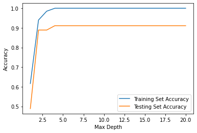

```
10 Fold Cross Validation for each Depth (Accuracy)
(1, 0.6196078431372549)
(2, 0.838562091503268)
(3, 0.8830065359477125)
(4, 0.8761437908496731)
(5, 0.8705882352941178)
(6, 0.8705882352941178)
(7, 0.8705882352941178)
(8, 0.8705882352941178)
(9, 0.8705882352941178)
(10, 0.8705882352941178)
(11, 0.8705882352941178)
(12, 0.8705882352941178)
(13, 0.8705882352941178)
(14, 0.8705882352941178)
(15, 0.8705882352941178)
(16, 0.8705882352941178)
(17, 0.8705882352941178)
(18, 0.8705882352941178)
(19, 0.8705882352941178)
(20, 0.8705882352941178)

10 Fold Cross Validation for each Depth (F1)
(1, 0.7480392156862745)
(2, 0.7480392156862745)
(3, 0.7480392156862745)
(4, 0.7480392156862745)
(5, 0.7480392156862745)
(6, 0.7480392156862745)
(7, 0.7480392156862745)
(8, 0.7480392156862745)
(9, 0.7480392156862745)
(10, 0.7480392156862745)
(11, 0.7480392156862745)
(12, 0.7480392156862745)
(13, 0.7480392156862745)
(14, 0.7480392156862745)
(15, 0.7480392156862745)
(16, 0.7480392156862745)
(17, 0.7480392156862745)
```

[output cut: 15 more lines]

```
(11, 0.6290510997661194)
(12, 0.6290510997661194)
(13, 0.6290510997661194)
(14, 0.6290510997661194)
(15, 0.6290510997661194)
(16, 0.6290510997661194)
(17, 0.6290510997661194)
(18, 0.6290510997661194)
(19, 0.6290510997661194)
(20, 0.6290510997661194)

Confusion Matrix for Max Depth=5
[[11  2  0]
 [ 1 20  1]
 [ 0  0 10]]
```

```python
#Part 2: Code (Decision Tree)

xtrain, xtest, ytrain, ytest = train_test_split(wine.data, wine.target, random_state=20)

trainacc = []
testacc = []
scoresa = []
scoresf = []
error = []

mdepth = range(1,21)

for i in mdepth:
    tree = DecisionTreeClassifier(max_depth=i, random_state=0)
    tree.fit(xtrain, ytrain)
    trainacc.append(tree.score(xtrain, ytrain))
    testacc.append(tree.score(xtest, ytest))
    a = cross_val_score(estimator=tree, X=wine.data, y=wine.target, cv=10)
    f = cross_val_score(estimator=knn, X=wine.data, y=wine.target, cv=10, scoring='f1_micro')
    e = cross_val_score(estimator=knn, X=wine.data, y=wine.target, cv=10, scoring='neg_root_mean_squared_error')
    scoresa.append((i, a.mean()))
    scoresf.append((i, f.mean()))
    error.append((i, -1*e.mean()))


mp.plot(mdepth, trainacc, label='Training Set Accuracy')
mp.plot(mdepth, testacc, label='Testing Set Accuracy')
mp.ylabel('Accuracy')
mp.xlabel('Max Depth')
mp.legend()
mp.show()

print("10 Fold Cross Validation for each Depth (Accuracy)")
for i in scoresa:
    print(i)

print()
print("10 Fold Cross Validation for each Depth (F1)")
for i in scoresf:
    print(i)

print()
print("10 Fold RMSE for each Number of Neighbors")
for i in error:
    print(i)

tree = DecisionTreeClassifier(max_depth=5, random_state=0)
tree.fit(xtrain, ytrain)
ypred = tree.predict(xtest)

print()
print("Confusion Matrix for Max Depth=5")
cm = confusion_matrix(ytest, ypred)
print(cm)
```

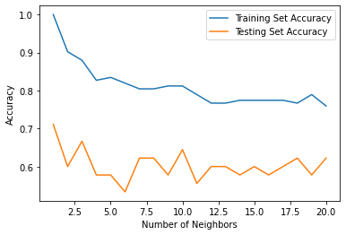

```
10 Fold Cross Validation for each Number of Neighbors (Accuracy)
(1, 0.7480392156862745)
(2, 0.6699346405228759)
(3, 0.7209150326797384)
(4, 0.6647058823529411)
(5, 0.6754901960784313)
(6, 0.6702614379084967)
(7, 0.669607843137255)
(8, 0.7088235294117646)
(9, 0.6977124183006536)
(10, 0.6973856209150326)
(11, 0.7143790849673202)
(12, 0.6918300653594771)
(13, 0.6918300653594771)
(14, 0.6862745098039216)
(15, 0.7199346405228757)
(16, 0.7088235294117646)
(17, 0.6973856209150326)
(18, 0.7143790849673202)
(19, 0.7032679738562091)
(20, 0.6977124183006536)

10 Fold Cross Validation for each Number of Neighbors (F1)
(1, 0.7480392156862745)
(2, 0.6699346405228759)
(3, 0.7209150326797384)
(4, 0.6647058823529411)
(5, 0.6754901960784313)
(6, 0.6702614379084967)
(7, 0.669607843137255)
(8, 0.7088235294117646)
(9, 0.6977124183006536)
(10, 0.6973856209150326)
(11, 0.7143790849673202)
(12, 0.6918300653594771)
(13, 0.6918300653594771)
(14, 0.6862745098039216)
(15, 0.7199346405228757)
(16, 0.7088235294117646)
(17, 0.6973856209150326)
```

[output cut: 15 more lines]

```
(11, 0.683001077138798)
(12, 0.681386636270781)
(13, 0.7263843104486386)
(14, 0.7185829419704228)
(15, 0.6727766188921499)
(16, 0.681283080237355)
(17, 0.6872820749340083)
(18, 0.6733524812421386)
(19, 0.7039087550105283)
(20, 0.6870046797364846)

Confusion Matrix
[[14  0  1]
 [ 3 11  4]
 [ 1  4  7]]
```

```python
#Part 2: Code (K-Nearest Neighbors)
xtrain, xtest, ytrain, ytest = train_test_split(wine.data, wine.target, stratify=wine.target, random_state=20)

trainacc = []
testacc = []
scoresa = []
scoresf = []
error = []

nnum = range(1,21)

for i in nnum:
    knn = KNeighborsClassifier(n_neighbors=i)
    knn.fit(xtrain,ytrain)
    trainacc.append(knn.score(xtrain, ytrain))
    testacc.append(knn.score(xtest, ytest))
    a = cross_val_score(estimator=knn, X=wine.data, y=wine.target, cv=10, scoring='accuracy')
    f = cross_val_score(estimator=knn, X=wine.data, y=wine.target, cv=10, scoring='f1_micro')
    e = cross_val_score(estimator=knn, X=wine.data, y=wine.target, cv=10, scoring='neg_root_mean_squared_error')
    scoresa.append((i, a.mean()))
    scoresf.append((i, f.mean()))
    error.append((i, -1*e.mean()))

mp.plot(nnum, trainacc, label='Training Set Accuracy')
mp.plot(nnum, testacc, label='Testing Set Accuracy')
mp.ylabel('Accuracy')
mp.xlabel('Number of Neighbors')
mp.legend()
mp.show()


print("10 Fold Cross Validation for each Number of Neighbors (Accuracy)")
for i in scoresa:
    print(i)

print()
print("10 Fold Cross Validation for each Number of Neighbors (F1)")
for i in scoresf:
    print(i)

print()
print("10 Fold RMSE for each Number of Neighbors")
for i in error:
    print(i)


knn = KNeighborsClassifier(n_neighbors=1)
knn.fit(xtrain,ytrain)
ypred = knn.predict(xtest)
print()
print("Confusion Matrix")
cm = confusion_matrix(ytest, ypred)
print(cm)
```

Part 2: Explanation

In this part, I use the wine dataset provided by SciKit Learn, originally published by UCI. This data looks at wine made by three different cultivars who used grapes from the same region of Italy. This dataset attempts to predict which cultivar made the wine. It does this by looking at 13 different numeric attributes of the wine. Below the section titled, "#Part 2: Code (initialization)," a full length description of these attributes can be found. The two additional algorithms I have chosen are K Nearest Neighbors (KNN) and Decision Trees. The hyperparameter for KNN is the number of neighbors and for decision trees, it's the max depth of the tree. For both of these, I did an exhaustive search method to find the optimal value. I chose a reasonable range of values and plotted their accuracy and then chose the value that had the highest accuracy with the testing set. The graphs are below the sections for each algorithm. I have also incuded the confusion matrix for the hyperparameter values that I chose for both of the algorithms. Looking at this and the graphs of their accuracies over many values of the hyperparameter, it is clear that the Decision Trees algorithm is outperforming the KNN algorithm, especially since the best accuracy that KNN has is just above 0.7 with K=1 compared to Decision Tree's best of 0.9 with a max depth of 5. While one can see that while a max depth of 5 is performing better for Decision Trees for the split I selected, a max depth of 3 is actually doing better using 10 fold cross validation. For KNN, the cross validation supports the idea that K=1 has the best performance overall. Under the cross validation scores for accuracy, I also provide the cross validation scores for f1 and the RMSE.